# 09Assignment

### CSCI E-89, Assignment 9

## Problem 1

Let's look at results from the analogizing in the Word2Vec script:

```python
Enter three words (EXIT to break): france paris russia

Word: france  Position in vocabulary: 303

Word: paris  Position in vocabulary: 1055

Word: russia  Position in vocabulary: 749

                                              Word              Distance
------------------------------------------------------------------------
                                            moscow              0.646027
                                        petersburg              0.523660
                                              olga              0.491379
                                           pushkin              0.485337
                                         petrograd              0.480138
                                      solzhenitsyn              0.480096
                                          kerensky              0.479217
                                            moskva              0.463020
                                             efron              0.459852
                                          nadezhda              0.457970
                                          tashkent              0.457597
                                           russian              0.456847
                                         tsarevich              0.451100
                                         pasternak              0.449692
                                         tsvetaeva              0.449592
                                            andrei              0.448314
                                              tsar              0.441902
                                         ostankino              0.441202
                                          taganrog              0.440379
                                      konstantinov              0.436819
                                      alexandrovna              0.435752
                                         tretyakov              0.433990
                                              kiev              0.431969
                                         leningrad              0.429489
                                             lenin              0.426275
                                            galina              0.426163
                                             pyotr              0.424281
                                             minsk              0.422468
                                            pravda              0.422464
                                            sergei              0.422145
                                             rsfsr              0.422045
                                         petrovich              0.418748
                                            berlin              0.417560
                                       vladivostok              0.416155
                                             irina              0.415685
                                       novosibirsk              0.414497
                                            vienna              0.413261
                                            gazeta              0.411785
                                          aeroflot              0.410293
                                    aleksandrovich              0.409508
Enter three words (EXIT to break): russia moscow france

Word: russia  Position in vocabulary: 749

Word: moscow  Position in vocabulary: 2854

Word: france  Position in vocabulary: 303

                                              Word              Distance
------------------------------------------------------------------------
                                             paris              0.672439
                                     fontainebleau              0.545707
                                          bordeaux              0.539906
                                           commune              0.539581
                                          brussels              0.515561
                                             rouen              0.510769
                                              lyon              0.505720
                                          mulhouse              0.492999
                                             dijon              0.492677
                                         cherbourg              0.491609
                                            french              0.488006
                                      montparnasse              0.484725
                                             passy              0.474932
                                             ecole              0.473197
                                           ferrand              0.467457
                                            nantes              0.466489
                                        strasbourg              0.466347
                                           bayonne              0.455594
                                    arrondissement              0.451361
                                             loire              0.450379
                                             ghent              0.449703
                                         marseille              0.449030
                                          clermont              0.448885
                                         normandie              0.447274
                                            rennes              0.443349
                                             turin              0.440247
                                             havre              0.436661
                                          provence              0.430831
                                          sorbonne              0.427695
                                            bastia              0.426440
                                            calais              0.426204
                                         partement              0.426069
                                          academie              0.426020
                                             arles              0.425582
                                          centrale              0.423869
                                             namur              0.423651
                                              haut              0.422715
                                              caen              0.421526
                                     universitaire              0.420965
                                                le              0.420898
Enter three words (EXIT to break): france paris greece
```

```python
Word: france  Position in vocabulary: 303

Word: paris  Position in vocabulary: 1055

Word: greece  Position in vocabulary: 1248

                                              Word              Distance
------------------------------------------------------------------------
                                            athens              0.585343
                                           eleusis              0.490729
                                             ionia              0.489042
                                            euboea              0.485895
                                      konstantinos              0.476998
                                            megara              0.465839
                                             greek              0.464866
                                           larissa              0.461344
                                            attica              0.461131
                                         athenians              0.460881
                                       heracleidae              0.459234
                                            ankara              0.457641
                                         venizelos              0.453349
                                          athenian              0.451605
                                            sparta              0.447223
                                             chios              0.441249
                                          colophon              0.439747
                                          hellenic              0.437704
                                           boeotia              0.435973
                                           argolid              0.435950
                                             troad              0.435244
                                          pergamon              0.435107
                                      thessaloniki              0.431575
                                            greeks              0.430753
                                           ionians              0.428996
                                           corinth              0.423336
                                           miletus              0.422475
                                            cretan              0.421731
                                            aegina              0.418496
                                       peloponnese              0.418165
                                            aegean              0.416342
                                            tiryns              0.414746
                                         mycenaean              0.414648
                                              rome              0.411769
                                             volos              0.408769
                                          thessaly              0.408689
                                         heraklion              0.405753
                                            abdera              0.404292
                                             mysia              0.403476
                                         lampsacus              0.403133
Enter three words (EXIT to break): france paris england

Word: france  Position in vocabulary: 303

Word: paris  Position in vocabulary: 1055

Word: england  Position in vocabulary: 316

                                              Word              Distance
------------------------------------------------------------------------
                                            london              0.545374
                                         leicester              0.526634
                                    leicestershire              0.507830
                                        nottingham              0.501777
                                     staffordshire              0.488359
                                         edinburgh              0.487401
                                       northampton              0.483398
                                            surrey              0.477600
                                          pembroke              0.476713
                                   buckinghamshire              0.476176
                                       lutterworth              0.468335
                                         worcester              0.463752
                                       westminster              0.462781
                                        manchester              0.459936
                                       oxfordshire              0.459181
                                         middlesex              0.457495
                                           ipswich              0.456847
                                        churchyard              0.455385
                                           bristol              0.454092
                                        birmingham              0.451449
                                         sheffield              0.450812
                                         newcastle              0.450761
                                      chesterfield              0.449793
                                         southwark              0.449257
                                              eton              0.448007
                                           balliol              0.445956
                                       bournemouth              0.444728
                                             elgar              0.444564
                                           glasgow              0.444320
                                         yorkshire              0.443666
                                         lichfield              0.442056
                                       glastonbury              0.441447
                                   gloucestershire              0.440988
                                      warwickshire              0.439001
                                         tavistock              0.438109
                                         liverpool              0.437839
                                        shropshire              0.435671
                                             stoke              0.435563
                                        warrington              0.435407
                                        lancashire              0.433978
Enter three words (EXIT to break): EXIT
```

We can see the model predicts the right word for all four, with pretty similar distances (between about $.54$ and $.67$).

I'm not exactly sure what the problem is asking for with the "last line of the text file," but here are the last lines of the text8 file and the vector.bin files, in case that's what's being asked:

```python
The text8 file is technically only one line, but here are the last few words:
e mass suicide verbatim to the romans the site today platform access to the fortress the site of masada was identified in one eight four two and extensively excavated in one nine six three one nine six five b

The vector.bin file is, of course, binary, but here's the utf-8 output of the last line:
ÕO<ê">EM=½èô˜½Ãƒ½&–?Pÿû>ÖUª¾TgL>%Ü½YOŒ¾ýœQ¾¤¡O>¿[e¾®áV=uÂ>„KO¾îñ¾Å‡«=>*-¾hDQ>Jf½²Îß¾gÓ>‰õ>\D¾©!€½l  ½-…<
```

## Problem 2

Borrowing code from the example notebook:

```python
import numpy as np
import gensim

# Get the interactive Tools for Matplotlib
%matplotlib notebook
%matplotlib inline
import matplotlib.pyplot as plt
plt.style.use('ggplot')

from sklearn.decomposition import PCA
from gensim.test.utils import datapath, get_tmpfile
from gensim.models import KeyedVectors
from gensim.scripts.glove2word2vec import glove2word2vec
```

```python
import os
cwd = os.getcwd()

glove_file = datapath(cwd + '\glove.6B\glove.6B.100d.txt')
word2vec_glove_file = get_tmpfile("glove.6B.100d.word2vec.txt")
glove2word2vec(glove_file, word2vec_glove_file)
```

```
(400000, 100)
```

```python
model = KeyedVectors.load_word2vec_format(word2vec_glove_file)
```

```python
def display_pca_scatterplot(model, words=None, sample=0):
    if words == None:
        if sample > 0:
            words = np.random.choice(list(model.vocab.keys()), sample)
        else:
            words = [ word for word in model.vocab ]

    word_vectors = np.array([model[w] for w in words])
    twodim = PCA().fit_transform(word_vectors)[:,:2]

    plt.figure(figsize=(6,6))
    plt.scatter(twodim[:,0], twodim[:,1], edgecolors='k', c='r')

    for word, (x,y) in zip(words, twodim):
        plt.text(x+0.05, y+0.05, word)

    for i in range(0, len(twodim), 2):
        plt.plot(twodim[:,0][i:i+2], twodim[:,1][i:i+2], 'bo-')
```

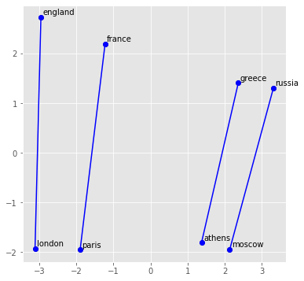

```python
display_pca_scatterplot(model, ['france','paris','russia','moscow','greece','athens','england','london'])
```

We can see that the vectors are roughly parallel, showing similar relationships between the words (as expected).

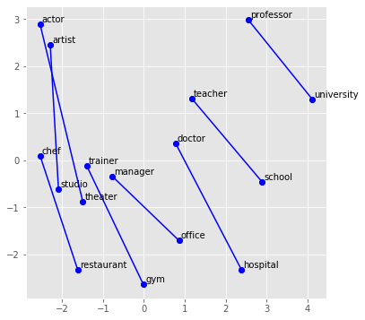

```python
new_analogies = ['chef', 'restaurant',
                 'doctor', 'hospital',
                 'teacher', 'school',
                 'professor', 'university',
                 'trainer', 'gym',
                 'manager', 'office',
                 'artist', 'studio',
                 'actor', 'theater',
                ]

display_pca_scatterplot(model, new_analogies)
```

This fun example looks pretty good. The vectors are very roughly parallel across all eight pairs. Artist-Studio and Manager-Office being the most off-axis makes sense to me (I think they're the most tenuous analogies).

## Problem 3

The above model used 100-dimensional data. Let's see if the relationships hold with 300-dimensional data:

```python
glove_file_300 = datapath(cwd + '\glove.6B\glove.6B.300d.txt')
word2vec_glove_file_300 = get_tmpfile("glove.6B.300d.word2vec.txt")
glove2word2vec(glove_file_300, word2vec_glove_file_300)
```

```
(400000, 300)
```

```python
model_300 = KeyedVectors.load_word2vec_format(word2vec_glove_file_300)
```

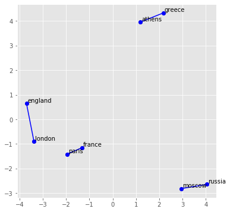

```python
display_pca_scatterplot(model_300, ['france','paris','russia','moscow','greece','athens','england','london'])
```

This looks very different from our model with 100 dimensions, but note that three of the vectors still look parallel. I'm not sure what's going on with England-London.

## Problem 4

Now let's try using t-SNE to visualize our data, rather than PCA:

```python
from sklearn.manifold import TSNE

def display_tsne_scatterplot(model, words=None, sample=0):
    if words == None:
        if sample > 0:
            words = np.random.choice(list(model.vocab.keys()), sample)
        else:
            words = [ word for word in model.vocab ]

    word_vectors = np.array([model[w] for w in words])
    twodim = TSNE().fit_transform(word_vectors)[:,:2]

    plt.figure(figsize=(6,6))
    plt.scatter(twodim[:,0], twodim[:,1], edgecolors='k', c='r')

    for word, (x,y) in zip(words, twodim):
        plt.text(x+0.05, y+0.05, word)

    for i in range(0, len(twodim), 2):
        plt.plot(twodim[:,0][i:i+2], twodim[:,1][i:i+2], 'bo-')
```

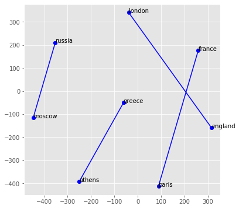

```python
display_tsne_scatterplot(model_300, ['france','paris','russia','moscow','greece','athens','england','london'])
```

This also looks very different but we're using an entirely different dimensionality reduction algorithm. This might be in line with what we should expect with t-SNE. Note that again, every vector except England-London is parallel.

## Problem 5

Let's try running our analogy experiments using spaCy:

```python
import spacy

nlp = spacy.load('en_core_web_lg')  # make sure to use larger model!
tokens = nlp(u'france paris russia moscow greece athens england london')
```

```python
# Saving tokens as variables
france = tokens[0]
paris = tokens[1]
russia = tokens[2]
moscow = tokens[3]
greece = tokens[4]
athens = tokens[5]
england = tokens[6]
london = tokens[7]

print(france.similarity(paris))
print(russia.similarity(moscow))
print(greece.similarity(athens))
print(england.similarity(london))
```

```
0.7916327
0.7492537
0.7560317
0.7389128
```

These look pretty good. Let's try a baseline to check

```python
print(france.similarity(moscow))
print(greece.similarity(london))
print(london.similarity(russia))
```

```
0.5035642
0.4903217
0.45057657
```

These values are worse, as expected!

```python
# We need to modify our scatterplot to work with spaCy
def spacy_pca_scatterplot(tokens, sample=0):
    words = [token.text for token in tokens]
    vectors = [token.vector for token in tokens]

    twodim = PCA().fit_transform(vectors)[:,:2]

    plt.figure(figsize=(6,6))
    plt.scatter(twodim[:,0], twodim[:,1], edgecolors='k', c='r')

    for word, (x,y) in zip(words, twodim):
        plt.text(x+0.05, y+0.05, word)

    for i in range(0, len(twodim), 2):
        plt.plot(twodim[:,0][i:i+2], twodim[:,1][i:i+2], 'bo-')
```

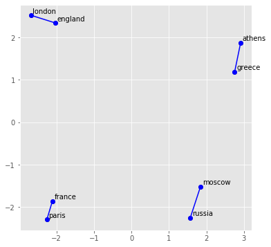

```python
spacy_pca_scatterplot(tokens)
```

This looks a lot like our results for our 300-dimensional gensim model, which is a good sign! Note that three of the pairs are again parallel, with just England-London perpendicular.

If we look all the way back to Problem 1, England-London seemed to have the lowest similarity using the Google Word2Vec script as well. I wonder why. Nevertheless, all the results seem coherent after accounting for that small oddity.